# nkelley_FinalHomeworkCode_03

Natalia Kelley

```r
library(curl)
```

```r
library(ggplot2)
library(tidyverse)
library("reshape2")
```

# Part One

Calculate the population mean and standard deviation for each quantitative random variable (height, weight, age, number of zombies killed, and years of education). NOTE: You will not want to use the built in var() and sd() commands as these are for samples.

```r
f <- curl("https://raw.githubusercontent.com/fuzzyatelin/fuzzyatelin.github.io/master/AN588_Fall21/zombies.csv")
d <- read.csv(f, header = TRUE, sep = ",", stringsAsFactors = FALSE)
#creates data frame from raw csv file

s <- select(d, "height", "weight", "age", "zombies_killed", "years_of_education")

#select function creates new data frame with only the columns selected from data frame d

ssq <- function(x) {sum((x-mean(x))^2)} #Function to calculate the sum of squares.
pop_var <- function(x) {ssq(x)/length(x)} #Function to calculate the variance of the population (note it is divided by "n" instead of by "n-1")
pop_sd <- function(x) {sqrt(pop_var(x))} #Function to calculate the standard deviation of the population.

#the above population functions courtesy of Miguel. I believe he calculated sd better than I did (because I just used regular sd() at first), so I inserted his function for sd into my cbind function below.

cbind(mean = apply(s, 2, mean), sd = apply(s, 2, pop_sd))
```

```
##                         mean        sd
## height              67.63010  4.307970
## weight             143.90748 18.391857
## age                 20.04696  2.963583
## zombies_killed       2.99200  1.747551
## years_of_education   2.99600  1.675704
```

```r
#combines data frames with shared column headers. x and y (in this case mean and sd) specify the new column headers. The new row headers are the old column headers. I inserted the apply functions as the data to populate the x/y columns with apply(s, 2, mean) extracting the means of the columns (1=rows, 2=columns) from df s. The same for apply(s, 2, sd) except this extracted the sd.
```

**Result:** mean sd height 67.63010 4.307970 weight 143.90748 18.391857 age 20.04696 2.963583 zombies_killed 2.99200 1.747551 years_of_education 2.99600 1.675704

# Part Two

Use {ggplot} to make boxplots of each of these variables by gender.

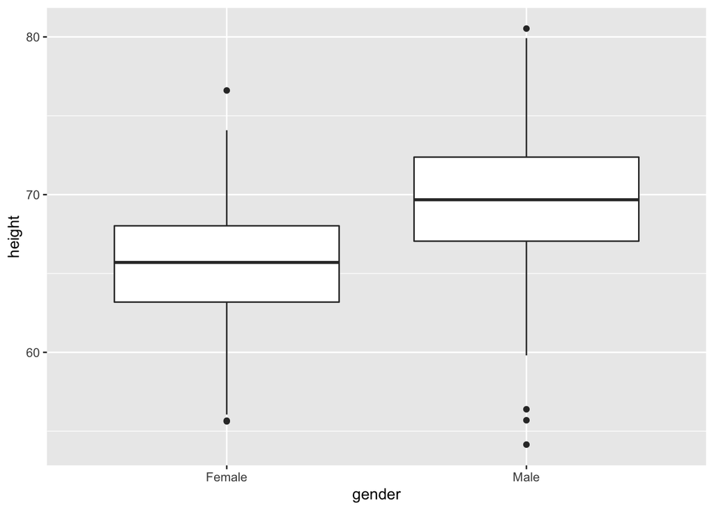

```r
f <- curl("https://raw.githubusercontent.com/fuzzyatelin/fuzzyatelin.github.io/master/AN588_Fall21/zombies.csv")

d <- read.csv(f, header = TRUE, sep = ",", stringsAsFactors = FALSE)
#creates data frame from raw csv file

GenderPlotHeight = ggplot(d, aes(x = gender, y = height)) + geom_boxplot()
GenderPlotHeight
```

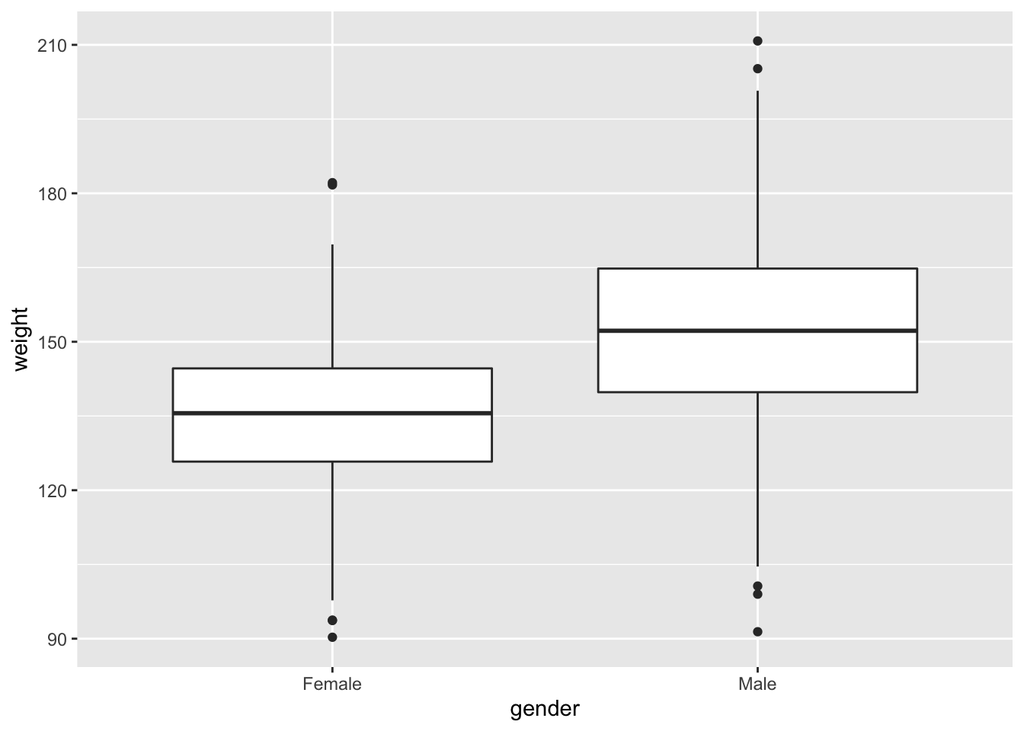

```r
#ggplot with data pulled from data frame d, with x representing gender and y representing height organized into a geom_boxplot()

GenderPlotWeight <- ggplot(d, aes(x = gender, y = weight)) + geom_boxplot()
GenderPlotWeight
```